# Female representation in Swiss cantons

Sara

2022-03-20

```r
library(tidyverse)
library(janitor)
library(sf)
library(geofacet)
```

# Getting the data

[This website](https://www.bfs.admin.ch/bfs/de/home/statistiken/politik/wahlen/frauen.html) provides an overview. Individual downloads are [general representation of women](https://www.bfs.admin.ch/bfs/de/home/statistiken/politik/wahlen/frauen.assetdetail.20324150.html), [women in the cantonal parliaments](https://www.bfs.admin.ch/bfs/de/home/statistiken/politik/wahlen/frauen.assetdetail.19784439.html) and [in the canton’s Regierungen](https://www.bfs.admin.ch/bfs/de/home/statistiken/politik/wahlen/frauen.assetdetail.19784439.html)

reading the file on the general representation of women

```r
women_repr <- readxl::read_excel("./data/je-d-17.02.09.01.xlsx", skip=2)
```

```
## * `` -> ...1
## * `` -> ...3
## * `` -> ...4
## * `` -> ...6
## * `` -> ...7
## * ...
```

```r
# names are two-tiered... manually rename
women_repr <- women_repr %>%
  select(year = 1, br_male = 2, br_female = 3,
         kreg_male = 5, kreg_female = 6,
         nr_male = 8, nr_female = 9,
         sr_male = 11, sr_female = 12,
         kparl_male = 14, kparl_female=15) %>%
  slice(-1) %>% # get rid of the first line - second part of index
  drop_na(br_male) # get rid of all comments

# clean year
women_repr <- women_repr %>%
  separate(year, into="year", sep="[ \\(]") %>%
  separate(year, into = "year", sep = "[\\/]")

# proper representation of missing values
# this will coerce the '...' into NAs which is perfectly fine
women_repr <- women_repr %>%
  mutate(across(everything(), as.numeric))
```

# a bit of a detour: women’s representation over time

based on [this article](https://blog.datawrapper.de/gendercolor/), I’d like to select specific colors for representing men and women. I’ll follow the Telegraph’s approach and relate to the suffragette movement with purple and green

```r
my_colors <- c("#00C4AA", "#8700F9")
```

```r
women_repr_long <- women_repr %>%
  pivot_longer(cols = c(-year),
               names_to = "category",
               values_to = "value") %>%
  separate(category, into = c("organ", "gender"), sep = "_")
```

and plot (function for plot?)

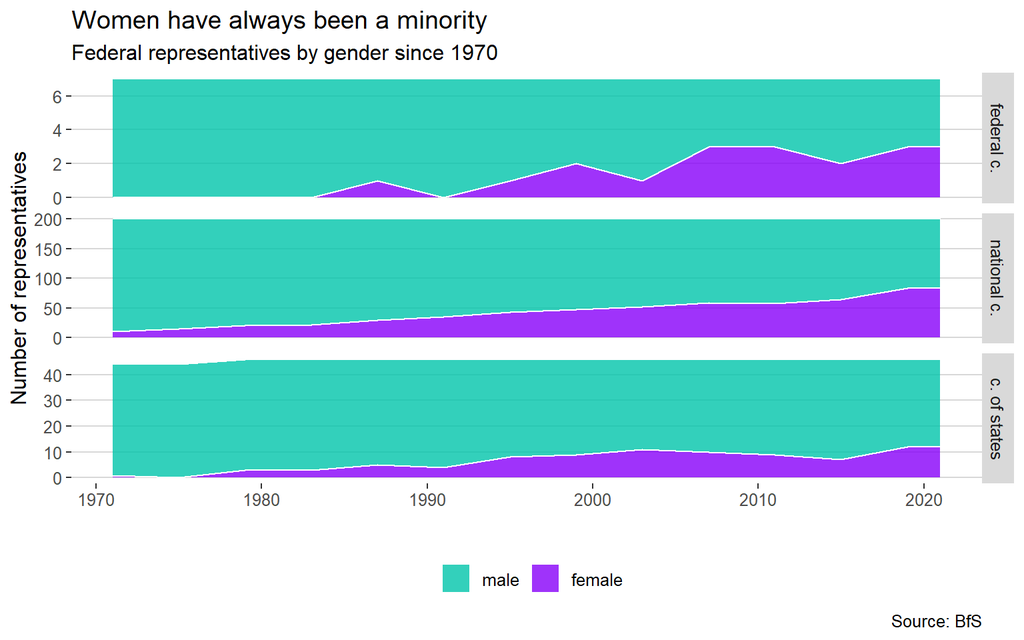

```r
# New facet label names
federals.labs <- c("federal c.", "national c.", "c. of states")
names(federals.labs) <- c("br", "nr", "sr")

p1 <- women_repr_long %>%
  filter(organ %in% c("br", "nr", "sr")) %>%
  ggplot(mapping = aes(x = year, y = value, fill = fct_rev(factor(gender)))) +
  geom_area(size=.5, colour="white", position="stack", alpha=0.8) +
  facet_grid(rows = vars(organ), scales = "free_y",
             labeller = labeller(organ = federals.labs)) +
  scale_fill_manual(values = my_colors, labels = c("male", "female")) +
  guides(fill = guide_legend(title = "")) +
  labs(title = "Women have always been a minority",
       subtitle = "Federal representatives by gender since 1970",
       x = "",
       y = "Number of representatives",
       caption = "Source: BfS") +
  ggthemes::theme_hc() +
  theme(panel.background = element_rect(fill = "transparent", colour = NA),
        plot.background = element_rect(fill = "transparent", colour = NA),
        legend.background = element_rect(fill = "transparent", colour = NA))
p1
```

```r
ggsave("federal_representatives.png", plot = p1, dpi=300,
       width = 7, height = 5)
```

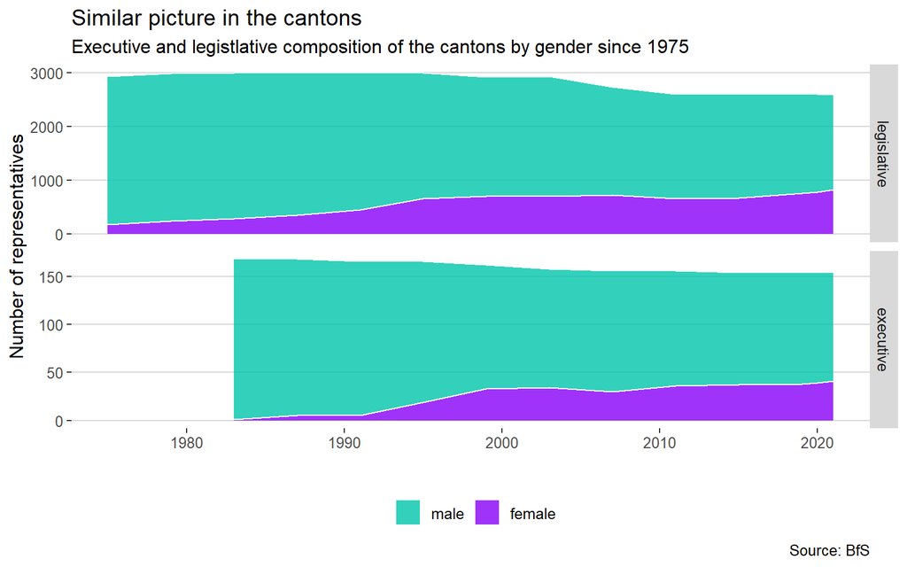

```r
# New facet label names
cantons.labs <- c("legislative", "executive")
names(cantons.labs) <- c("kparl", "kreg")

p2 <- women_repr_long %>%
  filter(organ %in% c("kparl", "kreg")) %>%
  ggplot(mapping = aes(x = year, y = value, fill = fct_rev(factor(gender)))) +
  geom_area(size=.5, colour="white", position="stack", alpha=0.8) +
  facet_grid(rows = vars(organ), scales = "free_y",
             labeller = labeller(organ = cantons.labs)) +
  scale_fill_manual(values = my_colors, labels = c("male", "female")) +
  guides(fill = guide_legend(title = "")) +
  labs(title = "Similar picture in the cantons",
       subtitle = "Executive and legistlative composition of the cantons by gender since 1975",
       x = "",
       y = "Number of representatives",
       caption = "Source: BfS") +
  ggthemes::theme_hc()+
  theme(panel.background = element_rect(fill = "transparent", colour = NA),
        plot.background = element_rect(fill = "transparent", colour = NA),
        legend.background = element_rect(fill = "transparent", colour = NA))
p2
```

```r
ggsave("cantonal_representatives.png", plot = p2, dpi=300,
       width = 7, height = 5)
```

right, that was kind of the overview. However, I do not have spatial information in this dataset, therefore need to import new data to get the spatial information.

# women in cantonal parliaments

```r
women_parl <- readxl::read_excel("./data/je-d-17.02.05.01.01.xlsx", skip = 1)
```

```
## * `` -> ...1
## * `` -> ...4
## * `` -> ...6
## * `` -> ...8
## * `` -> ...10
## * ...
```

```r
women_parl <- women_parl %>%
  select(canton = 1, year = 2, female = 43, male = 44) %>%
  slice(-1, -2) %>% # get rid of first line (part of index) and Switzerland
  drop_na(year) # get rid of all comments

# clean canton
women_parl <- women_parl %>%
  separate(canton, into = "canton", sep = "[[:digit:]]") %>%
  mutate(canton = str_trim(canton, side = "both"))
# make the numbers numeric type
women_parl <- women_parl %>%
  mutate(across(c("year", "female", "male"), as.numeric))

# calculate proportion
women_parl <- women_parl  %>%
  mutate(prop_female_parl = female / (female + male) *100)
```

# women in cantonal executives

```r
women_exec <- readxl::read_excel("./data/je-d-17.02.06.03.xlsx", skip = 1)
```

```
## * `` -> ...1
## * `` -> ...4
## * `` -> ...6
## * `` -> ...8
## * `` -> ...10
## * ...
```

```r
women_exec <- women_exec %>%
  select(canton = 1, year = 2, female = 27, male = 28) %>%
  slice(-(1:4)) %>%
  drop_na(year) %>%
  mutate(across(c("year", "female", "male"), as.numeric))

# clean canton
women_exec <- women_exec %>%
  separate(canton, into = "canton", sep = "[[:digit:]]") %>%
  mutate(canton = str_trim(canton, side = "both"))

# calculate proportion
women_exec <- women_exec %>%
  mutate(prop_female_exec = female / (male + female) *100)
```

check whether the names of the cantons are identical

```r
is_equal <- (women_exec %>% arrange(canton) %>% pull(canton)) == (women_parl %>% arrange(canton) %>% pull(canton))
sum(is_equal)
```

```
## [1] 25
```

hmm. even after trimming, there is one which is not the same.

```r
women_exec %>%
  arrange(canton) %>%
  filter(!is_equal)
```

```
## # A tibble: 1 x 5
##   canton       year female  male prop_female_exec
##   <chr>       <dbl>  <dbl> <dbl>            <dbl>
## 1 Solothurn p  2021      3     2               60
```

that seems to be a typo? I will change this manually

```r
women_exec <- women_exec %>%
  arrange(canton)

women_exec[!is_equal,1] <- "Solothurn"
```

rename the Appenzells to what they will be called below

```r
ausserrhoden_index <- (women_exec$canton == "Appenzell A. Rh.")
innerrhoden_index <- (women_exec$canton == "Appenzell I. Rh.")
women_exec[ausserrhoden_index, 1] <- "Appenzell Ausserrhoden"
women_parl[ausserrhoden_index, 1] <- "Appenzell Ausserrhoden"
women_exec[innerrhoden_index, 1] <- "Appenzell Innerrhoden"
women_parl[innerrhoden_index, 1] <- "Appenzell Innerrhoden"
```

anyway need to have a translation tibble, as some of the cantons below are not German

```r
women_exec %>%
  arrange(canton) %>%
  pull(canton)
```

[output not shown]

ah. the order isn’t quite the same. therefore make a translation tibble

```r
canton_translation <- tribble(
  ~code, ~name, ~canton,
  "AG", "Aargau", "Aargau",
  "AI", "Appenzell Innerrhoden", "Appenzell I. Rh.",
  "AR", "Appenzell Ausserrhoden", "Appenzell A. Rh.",
  "BE", "Bern", "Bern",
  "BL", "Basel-Landschaft", "Basel-Landschaft",
  "BS", "Basel-Stadt", "Basel-Stadt",
  "FR", "Fribourg", "Freiburg",
  "GE", "Genève", "Genf",
  "GL", "Glarus", "Glarus",
  "GR", "Graubünden", "Graubünden",
  "JU", "Jura", "Jura",
  "LU", "Luzern", "Luzern",
  "NE", "Neuchâtel", "Neuenburg",
  "NW", "Nidwalden", "Nidwalden",
  "OW", "Obwalden", "Obwalden",
  "SG", "St. Gallen", "St. Gallen",
  "SH", "Schaffhausen", "Schaffhausen",
  "SO", "Solothurn", "Solothurn",
  "SZ", "Schwyz", "Schwyz",
  "TG", "Thurgau", "Thurgau",
  "TI", "Ticino", "Tessin",
  "UR", "Uri", "Uri",
  "VD", "Vaud", "Waadt",
  "VS", "Valais", "Wallis",
  "ZG", "Zug", "Zug",
  "ZH", "Zürich", "Zürich",
)
```

## generate binned/discrete values

generate discrete values - for parliament

```r
quantile_vec_parl <- women_parl %>%
  pull(prop_female_parl) %>%
  quantile(probs = c(0, 0.25, 0.5, 0.75, 1), na.rm = TRUE)

quantile_vec_parl
```

```
##       0%      25%      50%      75%     100%
##  9.00000 25.11364 31.71429 34.37500 58.00000
```

```r
labels_parl <- tibble(
  lab1 = quantile_vec_parl,
  lab2 = c(quantile_vec_parl[2:length(quantile_vec_parl)], NA)
) %>%
  slice(1:n() - 1) %>% # We remove the last row, since it has no meaning
  mutate_all(round, digits = 0) %>% # We remove digits after the 0
  mutate_all(paste0, "%") %>% # We add the percentage sign after the digits
  mutate(labs = paste(lab1, lab2, sep = " to "))

labels_parl
```

```
## # A tibble: 4 x 3
##   lab1  lab2  labs
##   <chr> <chr> <chr>
## 1 9%    25%   9% to 25%
## 2 25%   32%   25% to 32%
## 3 32%   34%   32% to 34%
## 4 34%   58%   34% to 58%
```

generate discrete values - for executives

```r
quantile_vec_exec <- women_exec %>%
  pull(prop_female_exec) %>%
  quantile(probs = c(0, 0.25, 0.5, 0.75, 1), na.rm = TRUE)

quantile_vec_exec
```

```
##        0%       25%       50%       75%      100%
##  0.000000  3.571429 20.000000 42.142857 71.428571
```

```r
labels_exec <- tibble(
  lab1 = quantile_vec_exec,
  lab2 = c(quantile_vec_exec[2:length(quantile_vec_exec)], NA)
) %>%
  slice(1:n() - 1) %>% # We remove the last row, since it has no meaning
  mutate_all(round, digits = 0) %>% # We remove digits after the 0
  mutate_all(paste0, "%") %>% # We add the percentage sign after the digits
  mutate(labs = paste(lab1, lab2, sep = " to "))

labels_exec
```

```
## # A tibble: 4 x 3
##   lab1  lab2  labs
##   <chr> <chr> <chr>
## 1 0%    4%    0% to 4%
## 2 4%    20%   4% to 20%
## 3 20%   42%   20% to 42%
## 4 42%   71%   42% to 71%
```

```r
women_exec <- women_exec %>%
  mutate(quantiles_exec = cut(prop_female_exec,
                              breaks = quantile_vec_exec,
                              labels = labels_exec$labs,
                              include.lowest = TRUE))

women_parl <- women_parl %>%
  mutate(quantiles_parl = cut(prop_female_parl,
                              breaks = quantile_vec_parl,
                              labels = labels_parl$labs,
                              include.lowest = TRUE))
```

# get the cartography part of the choropleth

download the swiss boundaries from [swissBOUNDARIES on opendata.swiss](https://opendata.swiss/en/dataset/swissboundaries3d-kantonsgrenzen)

```r
swiss <- st_read("./data/SHAPEFILE_LV95_LN02/swissBOUNDARIES3D_1_3_TLM_KANTONSGEBIET.shp") %>%
  janitor::clean_names()
```

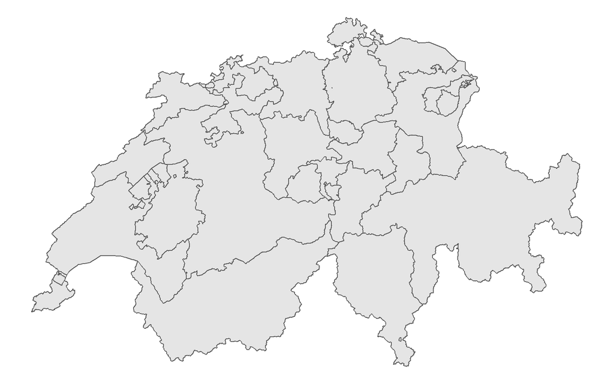

```r
# this is 3D data, but I only need 2D! (but apparently this is not permanent??)
swissm <- st_zm(swiss)

# sanity check plot
ggplot() +
  geom_sf(data = swiss) +
  theme_void()
```

join the tibbles

```r
swiss_combo <- swiss %>%
  dplyr::left_join(canton_translation, by = "name") %>%
  dplyr::left_join(women_exec %>% select(canton, prop_female_exec, quantiles_exec), by = "canton") %>%
  dplyr::left_join(women_parl %>% select(canton, prop_female_parl, quantiles_parl), by = "canton")
```

not binned, better to see the range/extremes:

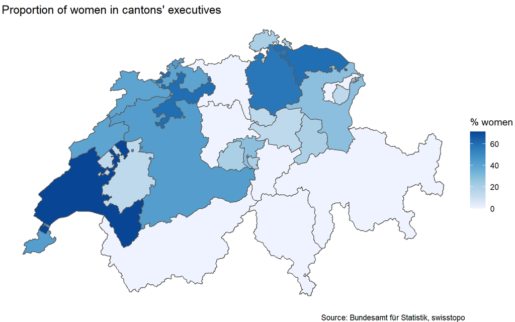

```r
ggplot() +
  geom_sf(
    data = swiss_combo,
    mapping = aes(fill = prop_female_exec)
  ) +
  scale_fill_distiller(direction = 1) +
  theme_void() +
  labs(title = "Proportion of women in cantons' executives",
       caption = "Source: Bundesamt für Statistik, swisstopo",
       fill = "% women")
```

and binned

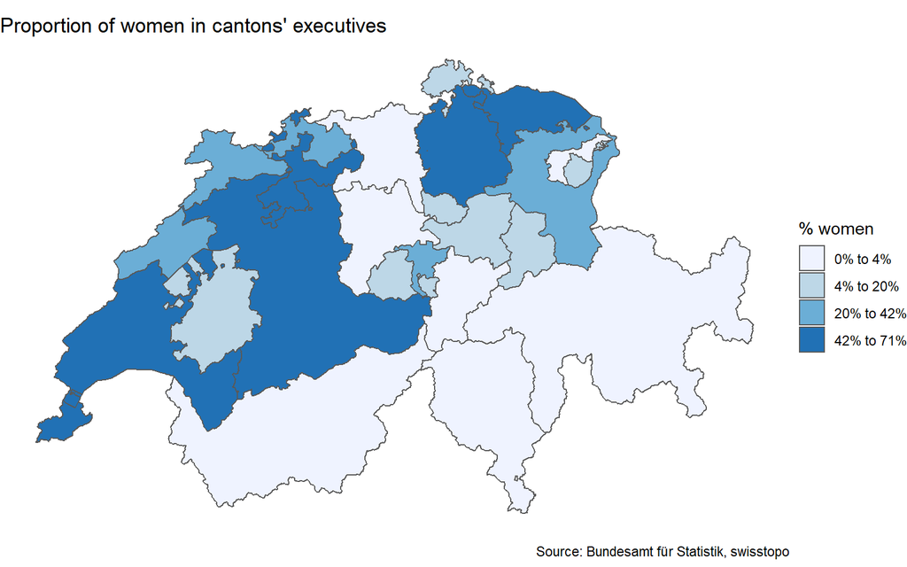

```r
ggplot() +
  geom_sf(
    data = swiss_combo,
    mapping = aes(fill = quantiles_exec)
  ) +
  scale_fill_brewer() +
  theme_void() +
  labs(title = "Proportion of women in cantons' executives",
       caption = "Source: Bundesamt für Statistik, swisstopo",
       fill = "% women")
```

continuous for parliament

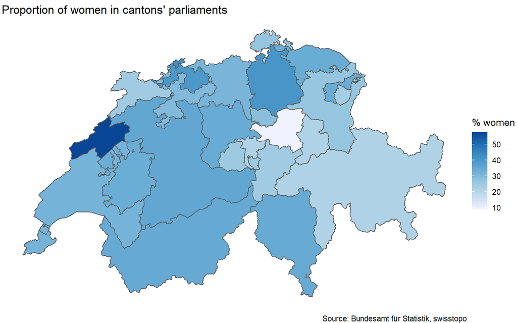

```r
ggplot() +
  geom_sf(
    data = swiss_combo,
    mapping = aes(fill = prop_female_parl)
  ) +
  scale_fill_distiller(direction = 1) +
  theme_void() +
  labs(title = "Proportion of women in cantons' parliaments",
       caption = "Source: Bundesamt für Statistik, swisstopo",
       fill = "% women")
```

see extremes better -basically one outlier in each direction!

and binned:

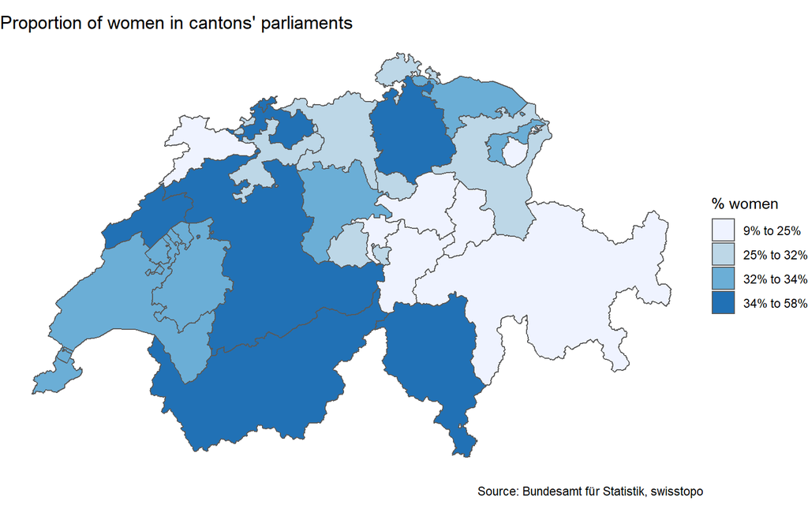

```r
ggplot() +
  geom_sf(
    data = swiss_combo,
    mapping = aes(fill = quantiles_parl)
  ) +
  scale_fill_brewer() +
  theme_void() +
  labs(title = "Proportion of women in cantons' parliaments",
       caption = "Source: Bundesamt für Statistik, swisstopo",
       fill = "% women")
```

# Turning the cantons into a grid

grid design for CH cantons from here

```r
ch_grid <- data.frame(
  code = c("SH", "BS", "TG", "AG", "JU", "BL", "ZH", "AI", "VD", "NE", "SO", "LU", "ZG", "SG", "AR", "FR", "BE", "NW", "GE", "SZ", "GL", "GR", "VS", "OW", "UR", "TI"),
  name_local = c("Schaffhausen", "Basel-Stadt", "Thurgau", "Aargau", "Jura", "Basel-Landschaft", "Zürich", "Appenzell-Innerrhoden", "Vaud", "Neuchâtel", "Solothurn", "Luzern", "Zug", "St.Gallen", "Appenzell-Ausserrhoden", "Fribourg", "Bern", "Nidwalden", "Genève", "Schwyz", "Glarus", "Graubünden", "Valais", "Obwalden", "Uri", "Ticino"),
  name_de = c("Schaffhausen", "Basel-Stadt", "Thurgau", "Aargau", "Jura", "Basel-Landschaft", "Zürich", "Appenzell-Innerrhoden", "Waadt", "Neuenburg", "Solothurn", "Luzern", "Zug", "St.Gallen", "Appenzell-Ausserrhoden", "Freiburg", "Bern", "Nidwalden", "Genf", "Schwyz", "Glarus", "Graubünden", "Wallis", "Obwalden", "Uri", "Tessin"),
 name_en = c("Schaffhausen", "Basel-City", "Thurgovia", "Argovia", "Jura", "Basel-Country", "Zurich", "Appenzell Inner-Rhodes", "Vaud", "Neuchâtel", "Solothurn", "Lucerne", "Zug", "St.Gallen", "Appenzell Outer-Rhodes", "Fribourg", "Bern", "Nidwalden", "Geneva", "Schwyz", "Glarus", "Grisons", "Valais", "Obwalden", "Uri", "Ticino"),
  row = c(2, 2, 3, 3, 3, 3, 3, 3, 4, 4, 4, 4, 4, 4, 4, 5, 5, 5, 5, 5, 5, 5, 6, 6, 6, 7),
  col = c(6, 4, 7, 5, 3, 4, 6, 8, 2, 3, 4, 5, 6, 7, 8, 3, 4, 5, 1, 6, 7, 9, 3, 5, 6, 6),
  stringsAsFactors = FALSE
)
```

```r
simple_combo <- ch_grid %>%
  dplyr::left_join(canton_translation, by = "code") %>%
  dplyr::left_join(women_exec %>% select(canton, prop_female_exec, quantiles_exec), by = "canton") %>%
  dplyr::left_join(women_parl %>% select(canton, prop_female_parl, quantiles_parl), by = "canton")
```

continuous plot of parliament

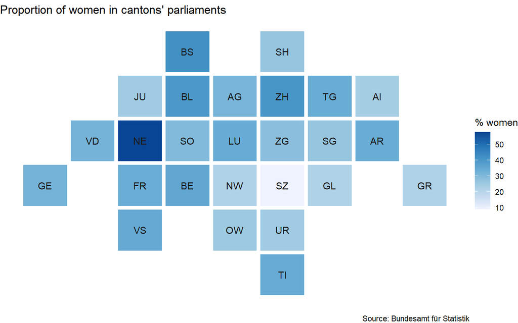

```r
ggplot(simple_combo, aes_string(x = "col", y = "row", label = "code")) +
  geom_tile(aes(fill = prop_female_parl), size = 2, color = "white") +
  geom_text(color = "grey10") +
  theme_void() +
  scale_fill_distiller(direction = 1) +
  scale_y_reverse() +
  labs(title = "Proportion of women in cantons' parliaments",
       caption = "Source: Bundesamt für Statistik",
       fill = "% women")
```

binned plot of parliament

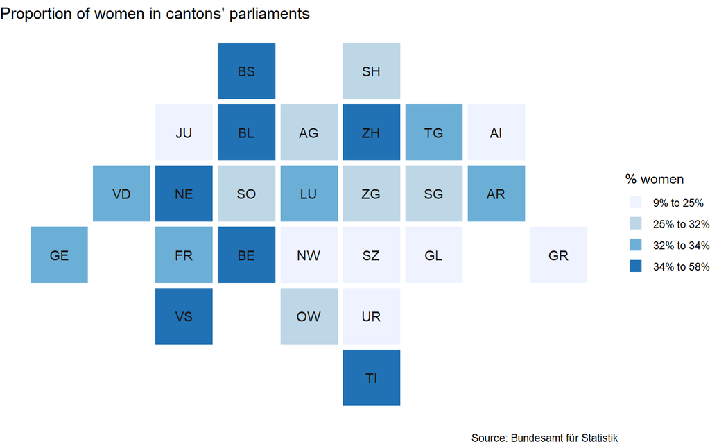

```r
p3 <- ggplot(simple_combo, aes_string(x = "col", y = "row", label = "code")) +
  geom_tile(aes(fill = quantiles_parl), size = 2, color = "white") +
  geom_text(color = "grey10") +
  theme_void() +
  scale_fill_brewer() +
  scale_y_reverse() +
  #theme(panel.border = element_blank()) +
  #theme(panel.grid = element_blank()) +
  labs(title = "Proportion of women in cantons' parliaments",
       caption = "Source: Bundesamt für Statistik",
       fill = "% women")
p3
```

```r
ggsave("cantonal_parliaments.png", plot = p3, dpi=300,
       width = 7, height = 5)
```

and the executives…

continuous

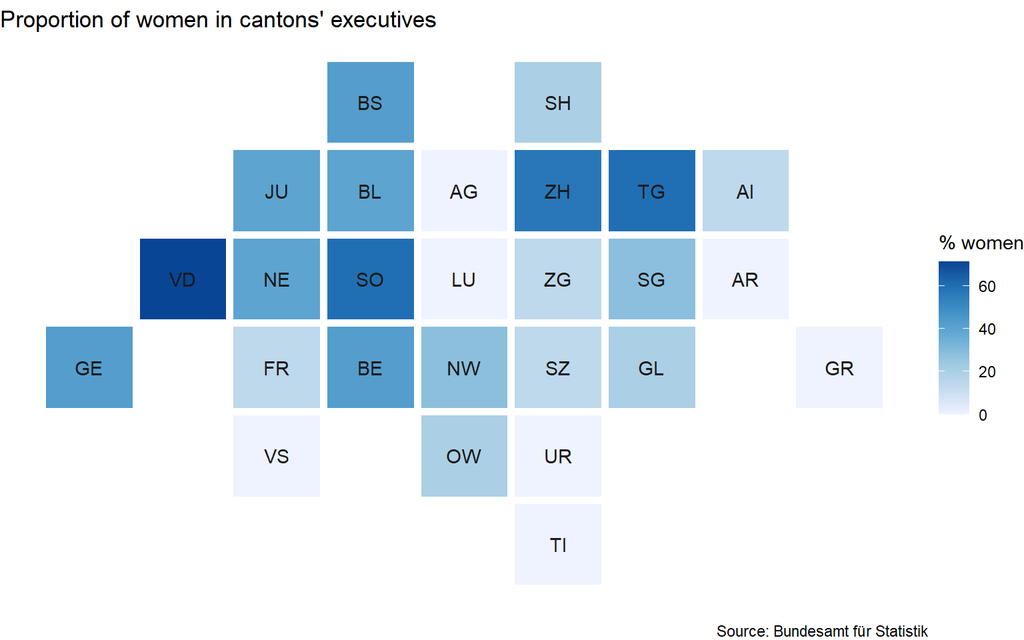

```r
ggplot(simple_combo, aes_string(x = "col", y = "row", label = "code")) +
  geom_tile(aes(fill = prop_female_exec), size = 2, color = "white") +
  geom_text(color = "grey10") +
  theme_void() +
  scale_fill_distiller(direction = 1) +
  scale_y_reverse() +
  labs(title = "Proportion of women in cantons' executives",
       caption = "Source: Bundesamt für Statistik",
       fill = "% women")
```

and binned

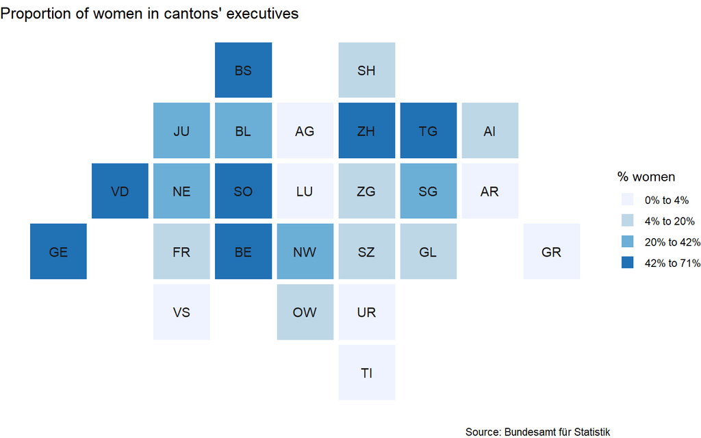

```r
p4 <- ggplot(simple_combo, aes_string(x = "col", y = "row", label = "code")) +
  geom_tile(aes(fill = quantiles_exec), size = 2, color = "white") +
  geom_text(color = "grey10") +
  theme_void() +
  scale_fill_brewer() +
  scale_y_reverse() +
  labs(title = "Proportion of women in cantons' executives",
       caption = "Source: Bundesamt für Statistik",
       fill = "% women")
p4
```

```r
ggsave("cantonal_executives.png", plot = p4, dpi=300,
       width = 7, height = 5)
```

## Take-aways

- geogrid did not work with text labels :-/
- binning the data for plotting it in maps makes it easier to read, but also somewhat ‘hides’ the extremes, e.g. the Schwyz with only 9% of women in parliament, with NE with 58% being the other extreme
- in general, women are still quite far from 50%!